# Sample Lecture - R

[figure not shown]

## Overview

This is a short and quick presentation of the available elements, which can be used to build up your lecture notes.

The big advantage is, that you have to build the document only once. You can include code, models, algorithms you are currently working on. Enrich them with notes and explanations for your students.

Once, it's time for lectures you just need to mark which elements should be included into the presentation and commit the changes to github. [Notebook-Classroom](https://github.com/hydrocode-de/notebook-classroom) will take care of the rest.

## Text Formatting

With markdown its **easy** to format text like *italics* or **bold and italics**.

By leaving a blank line, a new paragraph is started. Some inline $math^3_{i,j}$ can be added easily. Of course it's also possible to put formulas into their own line. $$E=mc^2$$ See the source for this formatted cell below:

```
With markdown its **easy** to format text like *italics* or _**bold and italics**_.

By leaving a blank line, a new paragraph is started. Some inline $math^3_{i,j}$ can be added easily. Of course it's also possible to put formulas into their own line.
$$E=mc^2$$
See the source for this formatted cell below:
```

## Code

It is also possible to include code that is not meant to be run (which would go into a code cell then). Most programming languages will be syntax-highlighed when included.

```
print('Like Python')
```

```
v <- "But also R"
```

```
cout << sprintf(buffer, "C++ is also %s", "known") << endl;
```

### More, More, More

of course there is way more. You will find some pretty good cheat-sheets out there: e.g. [this one](https://github.com/adam-p/markdown-here/wiki/Markdown-Cheatsheet)

## Running Code

The main advantage of using jupyter notebooks is obviously the ability to run code. We can perform calculations and explore the result interactively with the students. These cells even make it possible for students, who have never programed to change existing code with ease.

We will generate some $(x, y)$ tuples with $0 < x < 2\pi$ and $$ y = sin(x) + r $$ where $r$ is a random number $-0.1 < r < 0.1$

```r
# generate some data
x <- seq(0, 2*pi, length.out=100)

# sine
y <- sin(x) + runif(100, -.1, .1)
```

The notebook will render any output to StdOut and StdErr.

```r
y
```

1. 0.0738925523124635

2. 0.0268145549365031

3. 0.145166441011161

4. 0.129474043020808

5. 0.25405859085707

6. 0.368993065490665

7. 0.439491225921585

8. 0.340062956328082

9. 0.474784488457594

10. 0.630492288166307

11. 0.598603576661267

12. 0.607415629662038

13. 0.717659904521815

14. 0.728959089842827

15. 0.706884505189752

16. 0.844385616798945

17. 0.793192832687102

18. 0.810221270415133

19. 0.935741273835972

20. 0.941247470273406

21. 1.05252211356521

22. 1.02970304205643

23. 1.02449571844998

24. 0.978972237037482

25. 1.06425957908704

26. 0.954611431173008

27. 0.906175190530484

28. 1.05127307552802

29. 1.04314039166488

30. 0.991237801015609

31. 0.848597950784658

32. 0.913517737878566

33. 0.889211215311869

34. 0.85146105083622

35. 0.76934757449008

36. 0.861808547397305

37. 0.693257882450116

38. 0.724045440117371

39. 0.669449351868611

40. 0.523721037233717

41. 0.641522304193306

42. 0.61307751571349

43. 0.360993882356924

44. 0.359302954082185

45. 0.284696914385301

46. 0.293411415780988

47. 0.156700815978117

48. 0.0809591819597138

49. 0.0126528625559582

50. -0.0163126270417442

51. 0.0482510079294759

52. -0.0555705879066661

53. -0.124314262584756

54. -0.164449798893772

55. -0.207256349654031

56. -0.277658201045585

57. -0.429047574833775

58. -0.414342626272482

59. -0.504946652264885

60. -0.65375404175483

61. -0.633590832246936

62. -0.709490056243744

63. -0.752605748298121

64. -0.844793410230768

65. -0.773069614657362

66. -0.80137517896756

67. -0.934030973156765

68. -0.808722531097218

69. -0.856280940143471

70. -0.965394343638961

71. -0.932222009804332

72. -0.893857116330712

73. -0.971642716358921

74. -1.06723937466159

75. -1.0019808364743

76. -0.954792029278716

77. -1.00888800527154

78. -0.905518158905832

79. -1.05813407451475

80. -1.00674397714422

81. -0.838683890706629

82. -0.9097942418053

83. -0.965498892859688

84. -0.852020061577834

85. -0.801724231327944

86. -0.68969019386897

87. -0.655391346941903

88. -0.711853583848961

89. -0.660359811847494

90. -0.53111623060628

91. -0.499580501172342

92. -0.492636911052618

93. -0.349485384768385

94. -0.405313900022804

95. -0.407568368253576

96. -0.256958040315416

97. -0.140934329120271

98. -0.126006900942803

99. 0.0171708672053469

100. -0.0913833334576341

## Plotting

The maybe coolest feature is the ability to directly inject and show plots. The standard R plotting library is right away available and whenever a plotting object is passed to StdOut, the notebook will render it

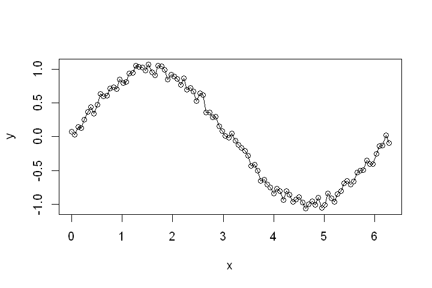

```r
options(repr.plot.width=6, repr.plot.height=4)
plot(x, y, type="o")
```

```r
df <- data.frame(x, y, sin(x) - y)
names(df) <- c('x', 'y', 'd')
p1 <- ggplot(df, aes(x=x, y=y)) +
        geom_line(color="red")
p2 <- ggplot() +
    geom_bar(data=df, aes(x=x, y=d), stat="identity",
             fill="blue", show.legend=F, width=0.02)
```

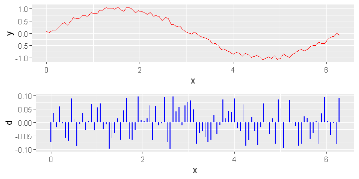

```r
options(repr.plot.width=6, repr.plot.height=3)
grid.arrange(p1, p2, nrow=2)
```

## Videos

Sometimes it's very helpful to include a video into a notebook. There are various ways how to do that. As Notebooks are capable of rendering HTML tags, you can include the video using a ordinary `iframe`. This is however not a good idea, as many Markdown processors will exclude tags like `<script>`, `<style>` or `<iframe>` from the markdown source before rendering it. Thus, we need the `vembedr` package

```r
embed_youtube('XTsaZRKx9UI', width=840, height=450) %>% use_start_time("5s")
```

[video not shown]

## Tables

There are many way to include tables. You can use Markdown markup to create tables. You can use HTML `<table>` tags. This is both fine, but a lot of work if you need to create large tables.

The third option is to use code cells to render tables. I.e. `data.frame` objects will render to tables if you print them to StdOut. This way you can keep the table data in a csv and read and render it in a one-liner.

### Markdown

This table:

| head 1 | head 2 | head 3 |
| --- | --- | --- |
| cell 1 | cell 2 | cell 3 |
| cell 4 | cell 5 | cell 6 |
| cell 7 | cell 8 | cell 9 |

can be created like:

```
| head 1 | head 2 | head 3 |
|--------|--------|--------|
| cell 1 | cell 2 | cell 3 |
| cell 4 | cell 5 | cell 6 |
| cell 7 | cell 8 | cell 9 |
```

### HTML

The same as HTML table:

| head 1 | head 2 | head 3 |
| --- | --- | --- |
| cell 1 | cell 2 | cell 3 |
| cell 4 | cell 5 | cell 6 |
| cell 7 | cell 8 | cell 9 |

can be created like:

```
<table>
    <tr><th>head 1</th><th>head 2</th><th>head 3</th></tr>
    <tr><td>cell 1</td><td>cell 2</td><td>cell 3</td></tr>
    <tr><td>cell 4</td><td>cell 5</td><td>cell 6</td></tr>
    <tr><td>cell 7</td><td>cell 8</td><td>cell 9</td></tr>
</table>
```

### R

```r
df
```

[output not shown]